# Waveform CC differential times for every v5.1 family

D-B093, catalog v6.0 NLL-coherence stage. Built 2026-11-25 19:54. Code: branch tomo/cc-dt-all (b5_ccall_*.py; measurement b5_cc_measure of tomo/cc-dt, unchanged). Output: `/wd1/mdenolle_data/tomo_v1/cc_dt_all`.

events**114,410**

pairs**7,722,146**

pair-station-phase rows**56,177,679**

accepted rows (dt.cc lines)**8,872,033**

pairs with >= 1 accepted**3,656,524**

## Scope

Every event of a v5.1 family (26,852) and every located earthquake within 3 km of a family event (87,558): 114,410 events, 1,613,295 picks (v4.1tc). Pairs: all pairs inside each family (6,634,619) and each event's 20 nearest neighbours within 3 km with at least 4 common station-phases (1,087,527 more).

## Per block

| block | family pairs | knn pairs | rows | measured | accepted | accepted / measured | dt.cc pairs | closure MAD P / S (ms) | triangles > 20 ms P / S | triangle sample | repeaters | repeater spread CC / catalog (ms) | clock-epoch rows (accepted) |
| --- | --- | --- | --- | --- | --- | --- | --- | --- | --- | --- | --- | --- | --- |
| axial | 148,576 | 319,465 | 3,910,153 | 3,808,679 | 719,413 | 19% | 280,751 | 1.7 / 1.8 | 2.9 % / 2.0 % | 1 | 2,140 | 3.0 / 42.6 | 0 (0) |
| blanco | 1,621,927 | 324,366 | 13,370,736 | 13,370,682 | 2,855,973 | 21% | 1,277,900 | 1.0 / 1.9 | 6.5 % / 4.2 % | 0.14 | 4,468 | 11.4 / 93.3 | 0 (0) |
| msh | 67,425 | 70,083 | 1,123,256 | 1,104,480 | 423,048 | 38% | 90,150 | 0.6 / 0.9 | 2.7 % / 0.2 % | 1 | 648 | 8.8 / 68.6 | 506 (233) |
| cascades | 62,043 | 25,334 | 1,176,279 | 1,176,070 | 742,724 | 63% | 82,723 | 0.4 / 0.5 | 0.3 % / 0.0 % | 0.77 | 2,532 | 7.0 / 65.7 | 364 (46) |
| endeavour | 1 | 216 | 1,174 | 1,174 | 287 | 24% | 155 | 1.9 / 1.6 | 5.7 % / 0.0 % | 1 | 0 | - / - | 0 (0) |
| explorer | 58,099 | 293 | 313,978 | 312,934 | 29,561 | 9% | 19,651 | 2.2 / 1.7 | 7.9 % / 2.9 % | 1 | 3 | 4.1 / 94.8 | 0 (0) |
| gorda | 2,792,349 | 21,291 | 19,934,617 | 19,931,817 | 1,438,461 | 7% | 881,675 | 2.1 / 2.6 | 12.9 % / 7.1 % | 0.42 | 489 | 9.3 / 87.5 | 0 (0) |
| jdf | 14,568 | 10,480 | 152,948 | 152,908 | 46,866 | 31% | 19,740 | 1.0 / 1.5 | 1.3 % / 0.3 % | 1 | 69 | 10.8 / 84.3 | 0 (0) |
| mendocino | 382,390 | 185,736 | 4,853,471 | 4,840,894 | 947,066 | 20% | 310,226 | 1.3 / 1.1 | 3.3 % / 3.0 % | 1 | 3,986 | 5.9 / 73.2 | 0 (0) |
| forearc | 1,444,397 | 65,253 | 10,179,033 | 10,176,113 | 1,113,048 | 11% | 603,646 | 2.3 / 1.3 | 8.1 % / 0.1 % | 0.5 | 3,339 | 7.4 / 80.8 | 0 (0) |
| onshore | 5,750 | 17,700 | 272,457 | 272,250 | 130,088 | 48% | 20,277 | 0.5 / 0.5 | 1.0 % / 0.1 % | 1 | 708 | 5.9 / 77.3 | 114 (13) |
| puget | 37,094 | 47,310 | 889,577 | 888,381 | 425,498 | 48% | 69,630 | 0.7 / 0.5 | 1.3 % / 1.1 % | 1 | 1,631 | 5.6 / 68.8 | 1,284 (646) |

## Loader check

b4_v6_ssst.coherences (reloc/v6-prep 6c78528d) read every cc_<block>.parquet: all pairs and coherences equal to pair_coherence.parquet.

## Station clock screen on the CC rows

Co-located pairs: 135,808 (1,452,101 accepted rows); 446 stations screened by month. Header time base: 115 candidate station-months at B019.PB, B024.PB, B027.PB, B030.PB, B031.PB, B032.PB, B035.PB, BB830.Z5, BB870.Z5, BLOW.UW, CMW.UW, F04D.TA, FS01B.7D, G02B.7D, G37B.7D, GB100.Z5, GB331.Z5, H04D.TA, I02D.TA, I04A.TA, IRO.UO, J20B.7D, L04D.TA, LCCR.UW, MG07.XD, MH07.XD, OZB.CN, RVW.UW, SHB.CN, VDB.CN. After the D-B090 correction: 109 at B019.PB, B024.PB, B027.PB, B030.PB, B031.PB, B032.PB, B035.PB, BB830.Z5, BB870.Z5, BLOW.UW, CMW.UW, F04D.TA, FS01B.7D, G02B.7D, G37B.7D, GB100.Z5, GB331.Z5, H04D.TA, I02D.TA, I04A.TA, IRO.UO, J20B.7D, L04D.TA, LCCR.UW, OZB.CN, RVW.UW, SHB.CN, VDB.CN. Nothing is applied.

| station | month | term (s) | P (s) | S (s) | rows | clock-like | pick-residual candidate |
| --- | --- | --- | --- | --- | --- | --- | --- |
| B019.PB | 2012-09 | +0.064 | 0.057 | 0.018 | 11 | False |  |
| B024.PB | 2010-02 | -0.236 | -0.461 | -0.002 | 17 | False |  |
| B024.PB | 2010-03 | -0.255 | -0.476 | -0.024 | 15 | False |  |
| B027.PB | 2011-04 | -0.087 | -0.097 | -0.063 | 11 | True |  |
| B030.PB | 2010-10 | -0.067 | -0.046 | -0.051 | 10 | False |  |
| B030.PB | 2014-06 | +0.052 | 0.037 | 0.058 | 68 | True |  |
| B031.PB | 2010-05 | -0.058 | - | -0.066 | 12 | False |  |
| B032.PB | 2010-04 | -0.059 | -0.005 | -0.063 | 13 | False |  |
| B032.PB | 2010-05 | -0.063 | -0.001 | -0.070 | 17 | False |  |
| B035.PB | 2014-03 | +0.092 | -0.002 | 0.067 | 11 | False |  |
| BB830.Z5 | 2014-08 | -0.818 | -0.818 | -0.771 | 33 | True |  |
| BB830.Z5 | 2014-09 | -0.710 | -0.719 | -0.664 | 26 | True |  |
| BB830.Z5 | 2014-10 | -0.579 | -0.586 | -0.538 | 21 | True | 2014-10-11 |
| BB830.Z5 | 2014-11 | -0.451 | -0.440 | -0.432 | 31 | True | 2014-10-11 |
| BB830.Z5 | 2014-12 | -0.337 | -0.315 | -0.313 | 23 | True | 2014-10-11 |
| BB830.Z5 | 2015-01 | -0.232 | -0.233 | -0.194 | 28 | True | 2014-10-11 |
| BB830.Z5 | 2015-02 | -0.075 | -0.079 | -0.037 | 27 | True | 2014-10-11 |
| BB830.Z5 | 2015-04 | +0.156 | 0.156 | 0.200 | 50 | True | 2014-10-11 |
| BB830.Z5 | 2015-05 | +0.261 | 0.269 | 0.297 | 33 | True | 2014-10-11 |
| BB830.Z5 | 2015-06 | +0.371 | 0.379 | 0.402 | 20 | True | 2014-10-11 |
| BB830.Z5 | 2015-07 | +0.521 | 0.527 | 0.550 | 35 | True | 2014-10-11 |
| BB830.Z5 | 2015-08 | +0.572 | 0.571 | 0.621 | 16 | True | 2014-10-11 |
| BB870.Z5 | 2014-11 | +0.052 | 0.057 | 0.047 | 48 | True | 2014-11-21 |
| BB870.Z5 | 2015-08 | -0.051 | -0.052 | -0.050 | 144 | True |  |
| BLOW.UW | 2010-10 | -0.052 | -0.045 | -0.060 | 16 | True |  |
| BLOW.UW | 2011-04 | -0.060 | -0.106 | -0.286 | 16 | True |  |
| BLOW.UW | 2011-05 | -0.051 | -0.097 | -0.016 | 10 | False |  |
| BLOW.UW | 2015-12 | -0.051 | -0.034 | -0.098 | 39 | True |  |
| BLOW.UW | 2016-02 | -0.063 | -0.054 | -0.116 | 13 | False |  |
| CMW.UW | 2010-04 | -0.071 | -0.036 | -0.140 | 20 | True |  |

[output cut: 79 more lines]

## QC figures

### axial

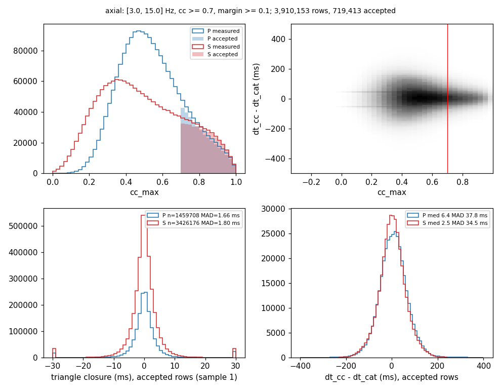

### blanco

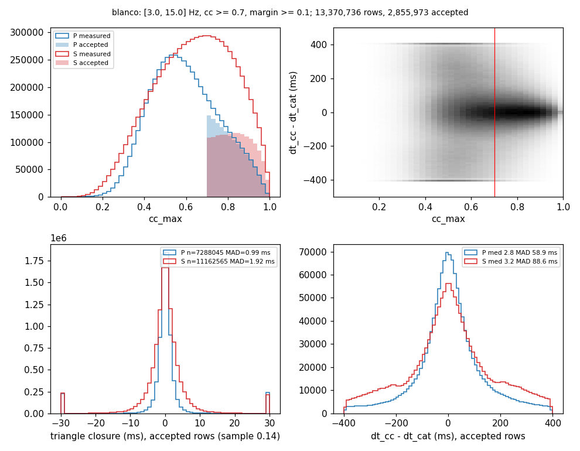

### msh

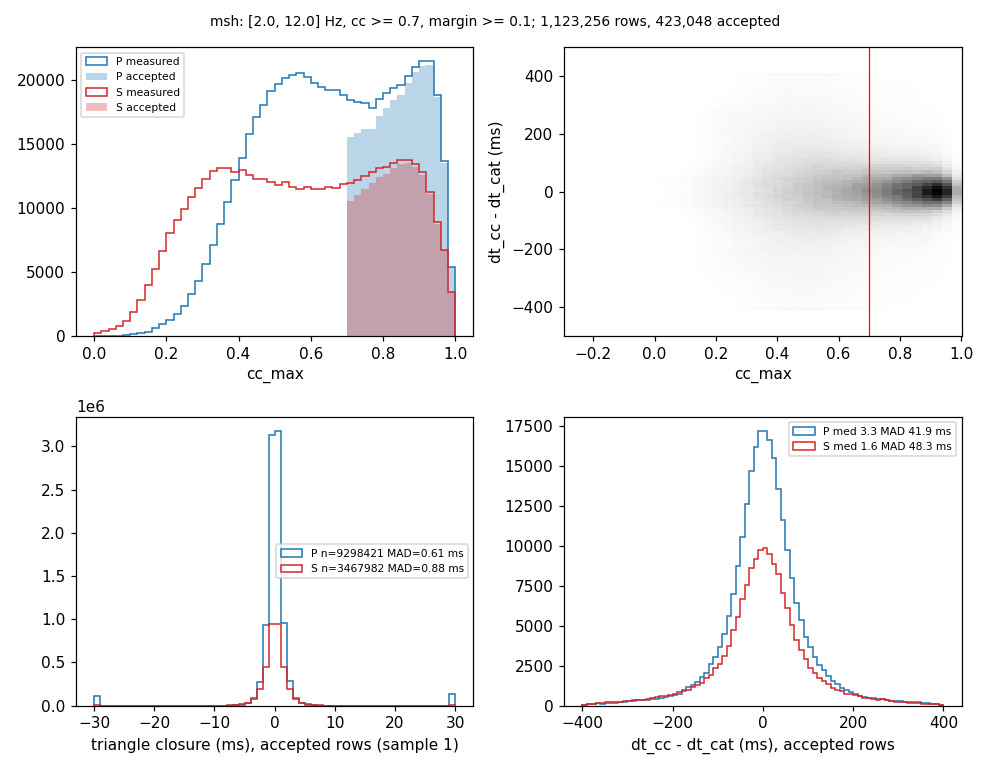

### cascades

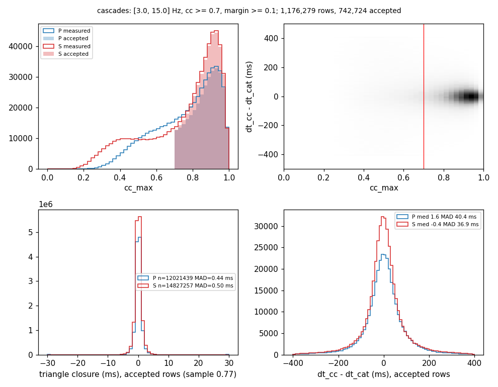

### endeavour

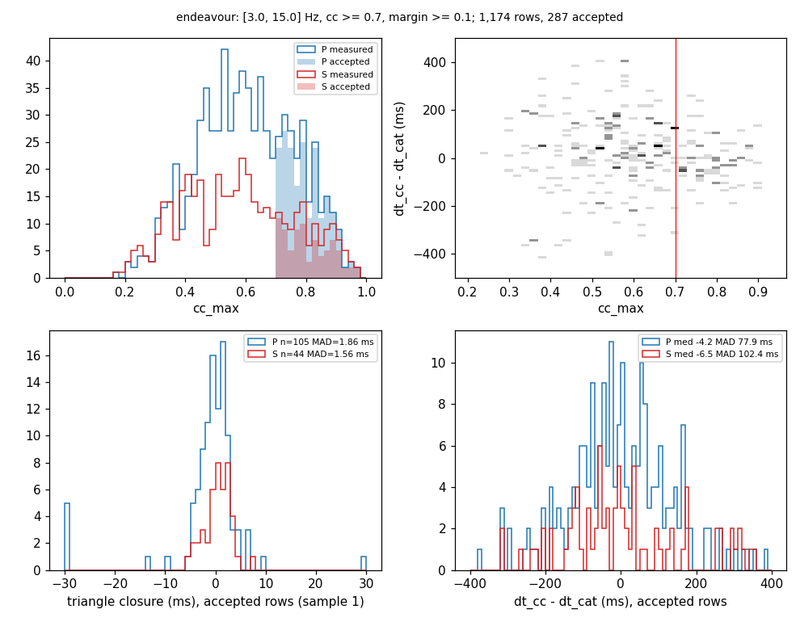

### explorer

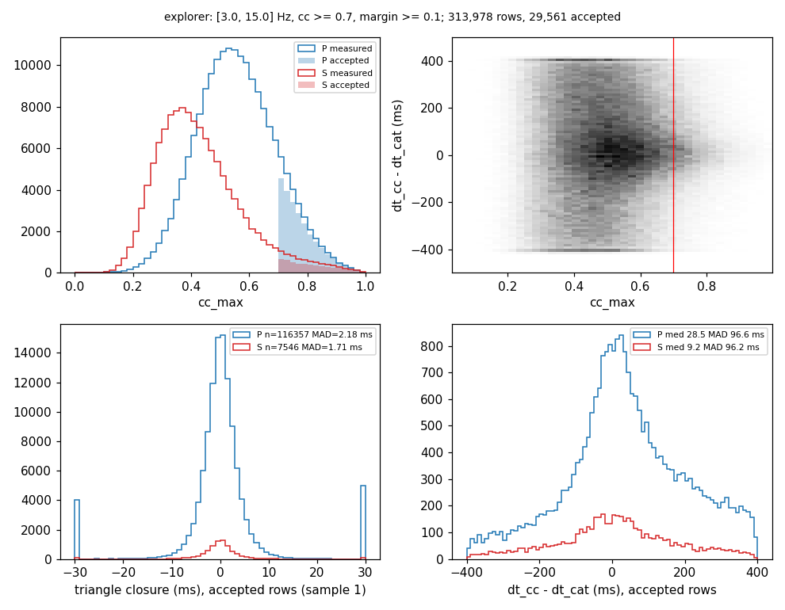

### gorda

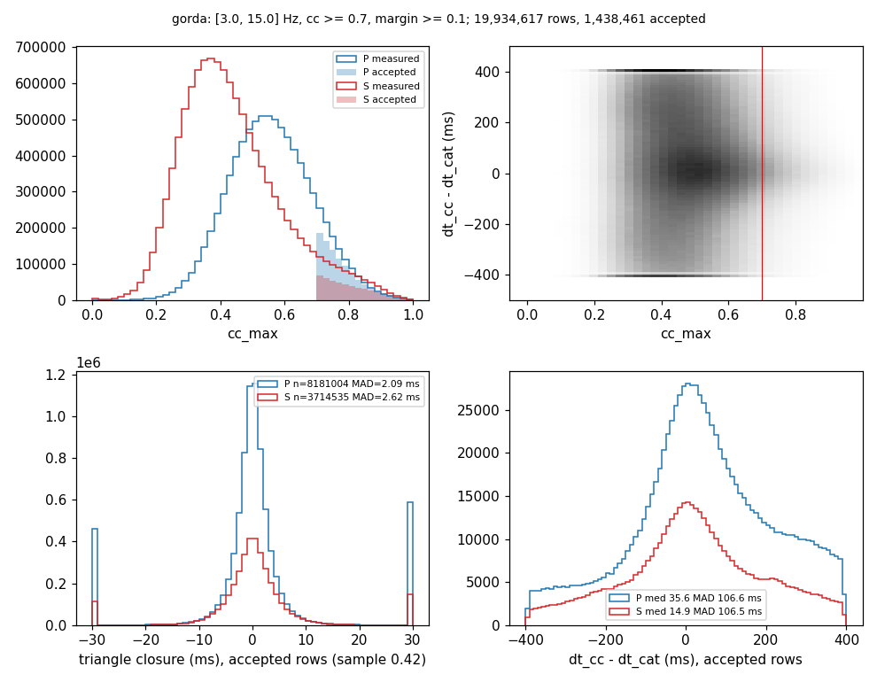

### jdf

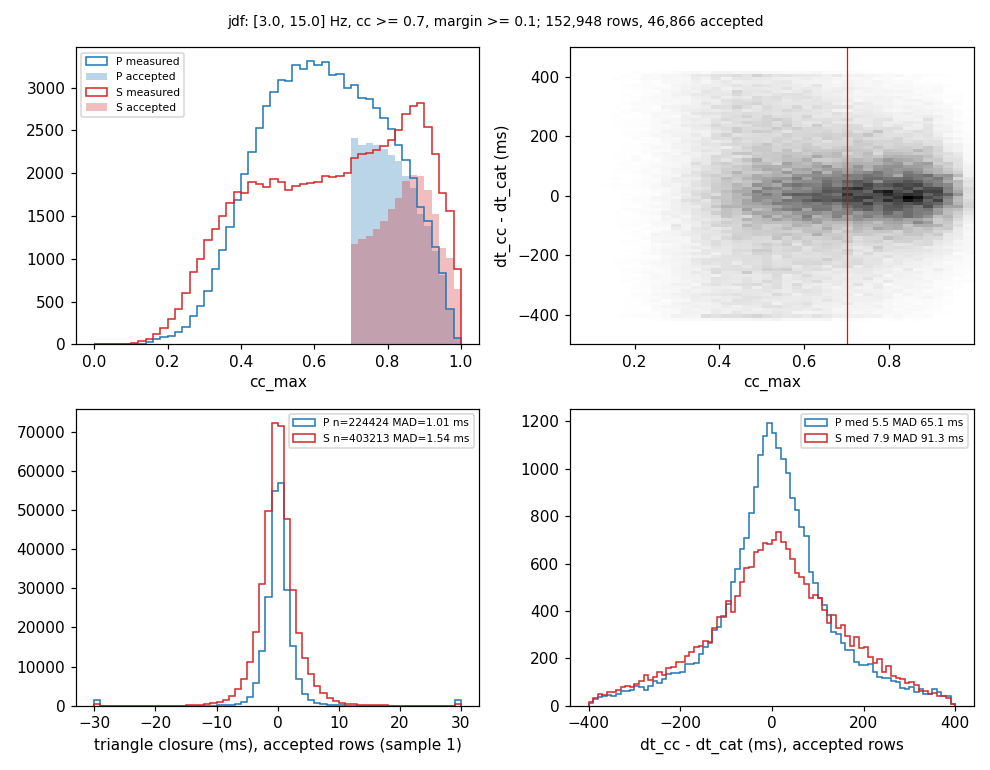

### mendocino

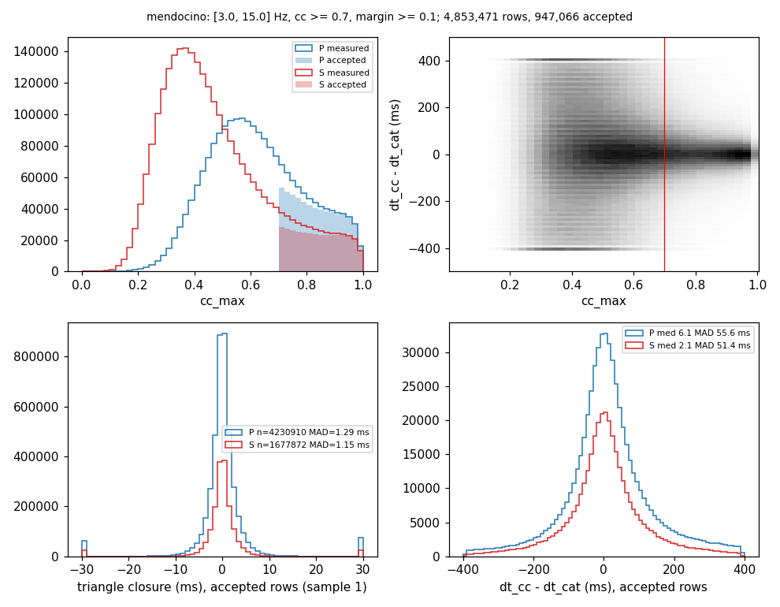

### forearc

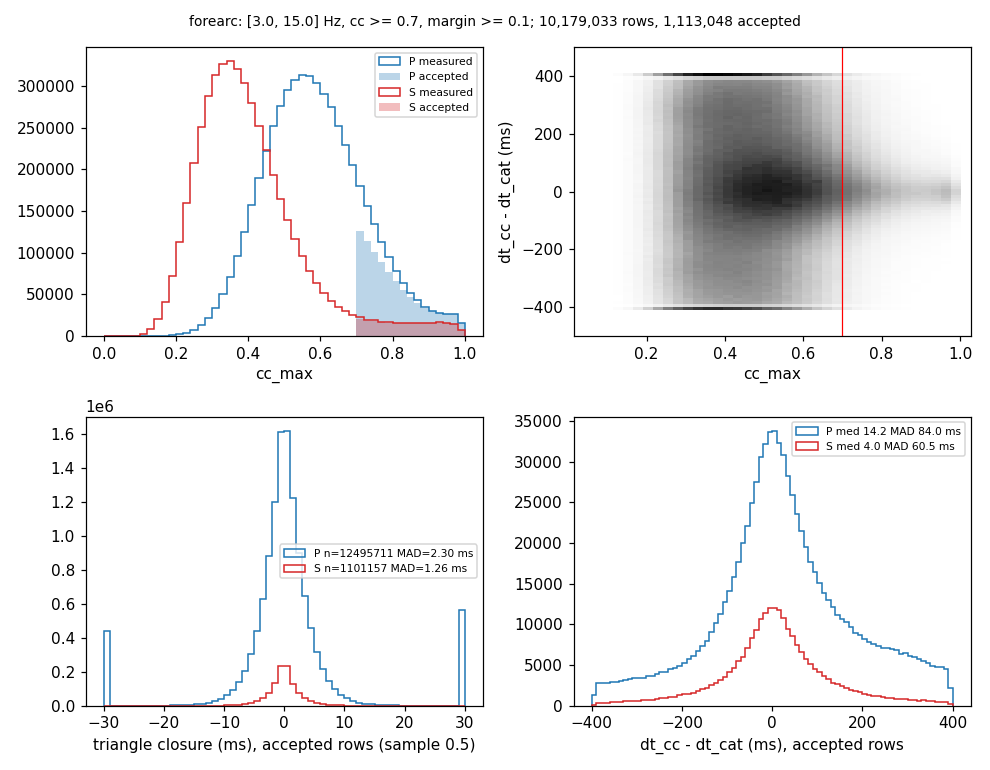

### onshore

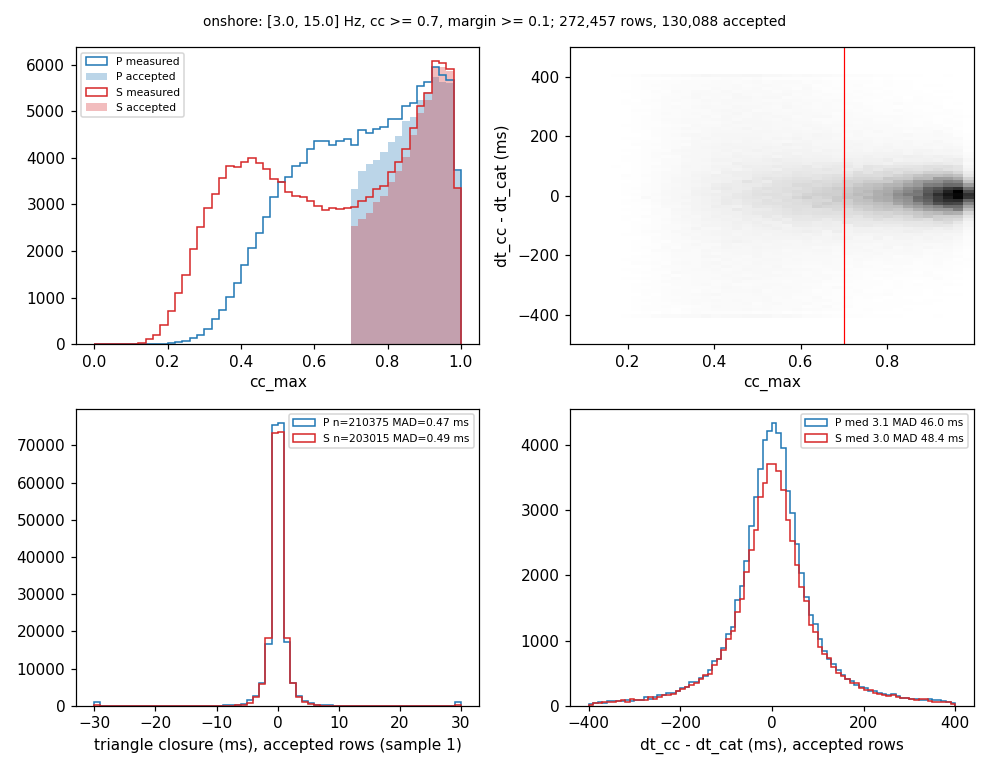

### puget

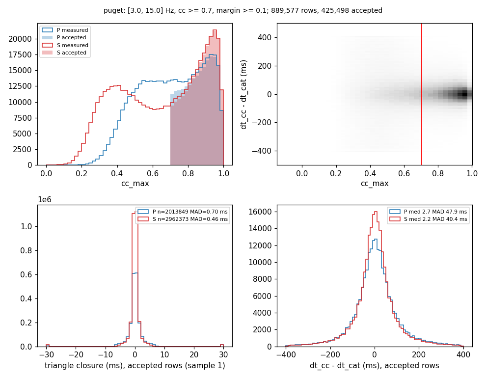